# An Analysis of NHS Primary Care Prescribing Information

In order to ensure a resiliantly resourced NHS an analysis of primary care prescribing was comissioned in order to identify any efficencies that could be made.

The following analysis is based on the 2018 GP Prescribing Dataset (2018)

GITHUB: https://github.com/imidean1/DMHR-Coursework

## This first section of code will deal with importing the packages needed as well as importing datasets

```python
# Prior to starting any analysis its good practice to import all libraries first
import pandasql as psql
import numpy as np
import pandas as pd
```

```python
#Setting working directorty
%cd /Users/imzy/Desktop/Python/Prescribe
! pwd
```

```
/Users/imzy/Desktop/Python/Prescribe
/Users/imzy/Desktop/Python/Prescribe
```

```python
#Importing Datasets
#The practice name dataset has no header so we create one
practice_names= pd.read_csv("prac_names.csv",names =["Year", "Practice_ID", "Pract_name", "Add_1","Add_2","City","Region","Post_Code"],skipinitialspace=True)

#There is an issue with white spaces which will make merges difficult later. We can remove them using the following approach.
def strip(text):
    try:
        return text.strip()
    except AttributeError:
        return text

def make_int(text):
    return int(text.strip('" '))

practice_names_edit = pd.read_table("prac_names.csv", sep=r',',
                      names=["Year", "Practice_ID", "Pract_name", "Add_1","Add_2","City","Region","Post_code"],
                      converters = {'Year' : strip,
                                    'Practice_ID' : strip,
                                    'Prac_name' : strip,
                                    'Add_1' : strip,
                                    'Add_2': strip,
                                    'City': strip,
                                    'Region':strip,
                                    'Post_code':strip
                                   })
display(practice_names_edit.head(5))
```

|  | Year | Practice_ID | Pract_name | Add_1 | Add_2 | City | Region | Post_code |
| --- | --- | --- | --- | --- | --- | --- | --- | --- |
| 0 | 201804 | A81001 | THE DENSHAM SURGERY | THE HEALTH CENTRE | LAWSON STREET | STOCKTON-ON-TEES | CLEVELAND | TS18 1HU |
| 1 | 201804 | A81002 | QUEENS PARK MEDICAL CENTRE | QUEENS PARK MEDICAL CTR | FARRER STREET | STOCKTON ON TEES | CLEVELAND | TS18 2AW |
| 2 | 201804 | A81004 | BLUEBELL MEDICAL CENTRE | TRIMDON AVENUE | ACKLAM | MIDDLESBROUGH |  | TS5 8SB |
| 3 | 201804 | A81005 | SPRINGWOOD SURGERY | SPRINGWOOD SURGERY | RECTORY LANE | GUISBOROUGH |  | TS14 7DJ |
| 4 | 201804 | A81006 | TENNANT STREET MEDICAL PRACTICE | TENNANT ST MEDICAL PRACT | TENNANT STREET | STOCKTON-ON-TEES | CLEVELAND | TS18 2AT |

```python
## We will now import the BNF lookup table - this will be used to identify drugs based on BNF code

chem_names = pd.read_csv("chem_names.csv")
display(chem_names.head(3))
```

|  | CHEMSUB | NAME |  |
| --- | --- | --- | --- |
| 0 | 0101010A0 | Alexitol Sodium ... | NaN |
| 1 | 0101010B0 | Almasilate ... | NaN |
| 2 | 0101010C0 | Aluminium Hydroxide ... | NaN |

```python
## We will now import the practice prescribing dataset - this will be the bulk of the data we use.
prac_pres = pd.read_table("prac_pres.csv",sep=r',')

prac_pres.rename(columns={"BNF CODE": "BNF_CODE", "BNF NAME                                    ":"BNF_NAME", "ITEMS  ": "ITEMS", "NIC        ": "NIC", "ACT COST   ": "ACT_COST"}, inplace = True)
display(prac_pres.head(5))
```

|  | SHA | PCT | PRACTICE | BNF_CODE | BNF_NAME | ITEMS | NIC | ACT_COST | QUANTITY | PERIOD |  |
| --- | --- | --- | --- | --- | --- | --- | --- | --- | --- | --- | --- |
| 0 | Q44 | RTV | Y04937 | 0401010Z0AAAAAA | Zopiclone_Tab 7.5mg | 6 | 1.56 | 2.12 | 63 | 201804 |  |
| 1 | Q44 | RTV | Y04937 | 0401020K0AAAHAH | Diazepam_Tab 2mg | 4 | 0.87 | 1.15 | 73 | 201804 |  |
| 2 | Q44 | RTV | Y04937 | 0401020K0AAAIAI | Diazepam_Tab 5mg | 2 | 0.46 | 0.56 | 35 | 201804 |  |
| 3 | Q44 | RTV | Y04937 | 0402010ABAAABAB | Quetiapine_Tab 25mg | 1 | 2.60 | 2.52 | 14 | 201804 |  |
| 4 | Q44 | RTV | Y04937 | 0402010ADAAAAAA | Aripiprazole_Tab 10mg | 1 | 1.53 | 1.53 | 14 | 201804 |  |

```python
#importing demographics dataset

prac_demo = pd.read_csv("prac_demo.csv",skipinitialspace=True)
display(prac_demo.head(5))
```

|  | PUBLICATION | EXTRACT_DATE | TYPE | CCG_CODE | ONS_CCG_CODE | CODE | POSTCODE | SEX | AGE | NUMBER_OF_PATIENTS |
| --- | --- | --- | --- | --- | --- | --- | --- | --- | --- | --- |
| 0 | GP_PRAC_PAT_LIST | 01APR2018 | GP | 00C | E38000042 | A83005 | DL1 3RT | ALL | ALL | 11826 |
| 1 | GP_PRAC_PAT_LIST | 01APR2018 | GP | 00C | E38000042 | A83006 | DL3 6HZ | ALL | ALL | 8044 |
| 2 | GP_PRAC_PAT_LIST | 01APR2018 | GP | 00C | E38000042 | A83010 | DL3 9JP | ALL | ALL | 14070 |
| 3 | GP_PRAC_PAT_LIST | 01APR2018 | GP | 00C | E38000042 | A83013 | DL1 4YL | ALL | ALL | 11298 |
| 4 | GP_PRAC_PAT_LIST | 01APR2018 | GP | 00C | E38000042 | A83031 | DL3 8SQ | ALL | ALL | 10109 |

```python
from pandasql import PandaSQL
pdsql = PandaSQL()
##After inspecting the practice names dataset we notice missing values for region - This will not impact our analysis later.
missing_region= pdsql("SELECT COUNT(DISTINCT Practice_ID) as counter FROM practice_names where Region is null ;")
print(missing_region)
```

```
   counter
0     1918
```

# Question 1 A

Identify all GP practices located in London.

Answer: In order to get the most accurate number it is better to take advantage of the CCG codes to identify practices as opposed to specifying a city or region.

```python
london = pdsql("select distinct(CODE) as Practice_ID from prac_demo where CCG_CODE in('07L','07M','07N','07P','07Q','07R','09A','07T','07V','07W','07X','08A','08C','08D','08E','08F','08G','07Y','08H','08J','08K','08L','08R','08M','08N','08P','08Q','08T','08V','08W','08X','08Y');")
practices_in_london=pdsql("select count(Practice_ID) as number_of_practices_in_london from london;")
display(practices_in_london)
```

|  | number_of_practices_in_london |
| --- | --- |
| 0 | 1323 |

## Question 1 B What is the Total number of patients registerd at london GP

Answer: We can take advantage of the practice ID's already identified and use a SQL subquery to avoid any messy joins

```python
total_london=pdsql('select sum(NUMBER_OF_PATIENTS) as total_london_pats from prac_demo where code in (select Practice_ID from london);')
display(total_london)
```

|  | total_london_pats |
| --- | --- |
| 0 | 9851208 |

# Question 1C What is The total number of prescriptions for patients in London

Answer: We can take advantage of the items column and perform a simple summation

```python
total_prescriptions =pdsql("select sum(ITEMS) AS total_prescriptions from prac_pres where PCT in('07L','07M','07N','07P','07Q','07R','09A','07T','07V','07W','07X','08A','08C','08D','08E','08F','08G','07Y','08H','08J','08K','08L','08R','08M','08N','08P','08Q','08T','08V','08W','08X','08Y');")
display(total_prescriptions)
```

|  | total_prescriptions |
| --- | --- |
| 0 | 10528133 |

# Question 1D What is the total actual cost of these prescriptions (using the ACT COST column)

Answer: The total cost for all ites is already reflected in the actual cost column  
therefore the total cost of prescription is sum of total costs

```python
## The dataset is rather large and clunky - we can make our queries quicker by making a london only subset
## First step is to select all data for london practices to save time
london_pres_data = pdsql("select * from prac_pres where PCT in ('07L','07M','07N','07P','07Q','07R','09A','07T','07V','07W','07X','08A','08C','08D','08E','08F','08G','07Y','08H','08J','08K','08L','08R','08M','08N','08P','08Q','08T','08V','08W','08X','08Y');")
```

```python
display(london_pres_data.head(5))
```

[output not shown]

```python
#Firstly lets create a column that calculates the total cost for all each drug
london_pres_data['total_cost'] =london_pres_data['ACT_COST']
```

```python
display(london_pres_data.head(5))
```

|  | SHA | PCT | PRACTICE | BNF_CODE | BNF_NAME | ITEMS | NIC | ACT_COST | QUANTITY | PERIOD |  | total_cost |
| --- | --- | --- | --- | --- | --- | --- | --- | --- | --- | --- | --- | --- |
| 0 | Q61 | 07L | F82001 | 0101010L0BEAAAI | Maalox Plus_Susp | 1 | 2.91 | 2.71 | 250 | 201804 |  | 2.71 |
| 1 | Q61 | 07L | F82001 | 0101021B0BEADAJ | Gaviscon Infant_Sach 2g (Dual Pack) S/F | 1 | 19.28 | 17.89 | 60 | 201804 |  | 17.89 |
| 2 | Q61 | 07L | F82001 | 0101021B0BEAFAH | Gaviscon_Liq Relief Peppermint | 2 | 27.75 | 25.76 | 1800 | 201804 |  | 25.76 |
| 3 | Q61 | 07L | F82001 | 0101021B0BEAIAL | Gaviscon Advance_Liq (Aniseed) (Reckitt) | 10 | 56.32 | 52.36 | 5500 | 201804 |  | 52.36 |
| 4 | Q61 | 07L | F82001 | 0101021B0BEBEAL | Gaviscon Advance_Liq (Peppermint) S/F | 13 | 82.92 | 77.26 | 7650 | 201804 |  | 77.26 |

```python
#Now we simply sum the total_cost coulmn to get our answer of total costs for london
total_cost_london = london_pres_data['total_cost'].sum()
print(total_cost_london)
```

```
77495848.00999998
```

# Question 1e: What are the top 10 most freequent drugs prescribed in london

Answer: We can take advantage of the BNF code as its a unique identifyer of each drug in the NHS styste,.

```python
# first lets find out the total quantity prescribed by medication
Total_presc_ldn = pdsql('select distinct(BNF_CODE) as BNF_CODE, sum(ITEMS) as SUM_ITEMS from london_pres_data group by 1 order by 2 desc;')
display(Total_presc_ldn.head(5))
```

|  | BNF_CODE | SUM_ITEMS |
| --- | --- | --- |
| 0 | 0103050P0AAAAAA | 240428 |
| 1 | 0601022B0AAABAB | 208255 |
| 2 | 0206020A0AAAAAA | 198459 |
| 3 | 0212000B0AAABAB | 182861 |
| 4 | 0209000A0AAABAB | 168718 |

```python
#Now we will use our lookup table to create a join and generate the top ten drugs presecibed in london
top_drugs_ldn = pdsql("select a.*, b.BNF_NAME from Total_presc_ldn a left outer join london_pres_data b on a.BNF_CODE = b.BNF_CODE group by a.BNF_CODE order by 2 desc;")
display(top_drugs_ldn.head(10))
```

|  | BNF_CODE | SUM_ITEMS | BNF_NAME |
| --- | --- | --- | --- |
| 0 | 0103050P0AAAAAA | 240428 | Omeprazole_Cap E/C 20mg |
| 1 | 0601022B0AAABAB | 208255 | Metformin HCl_Tab 500mg |
| 2 | 0206020A0AAAAAA | 198459 | Amlodipine_Tab 5mg |
| 3 | 0212000B0AAABAB | 182861 | Atorvastatin_Tab 20mg |
| 4 | 0209000A0AAABAB | 168718 | Aspirin Disper_Tab 75mg |
| 5 | 0206020A0AAABAB | 155712 | Amlodipine_Tab 10mg |
| 6 | 0212000B0AAACAC | 152073 | Atorvastatin_Tab 40mg |
| 7 | 0103050L0AAAAAA | 150071 | Lansoprazole_Cap 30mg (E/C Gran) |
| 8 | 0301011R0AAAPAP | 142599 | Salbutamol_Inha 100mcg (200 D) CFF |
| 9 | 0407010H0AAAMAM | 123929 | Paracet_Tab 500mg |

## Analysis:

The most common prescriptions appear to be related to chronic condtions and illnesses associated with age The top ten prescroptions are used to treat diabeties, high blood pressure, high cholesterol and asthma

# Question 1F: What where the 10 least prescribed drugs in london

Answer: To solve this question we can use the previous table (top_drugs_ldn) and sort by the opposite order

```python
bottom_drugs_ldn = pdsql('select * from top_drugs_ldn group by BNF_CODE order by 2 ;')
display (bottom_drugs_ldn.head(10))
```

|  | BNF_CODE | SUM_ITEMS | BNF_NAME |
| --- | --- | --- | --- |
| 0 | 0101010I0AAABAB | 1 | Mag Ox_Cap 100mg |
| 1 | 0101010I0AAALAL | 1 | Mag Ox_Tab 160mg |
| 2 | 0101010P0AAAAAA | 1 | Co-Simalcite_Susp 125mg/500mg/5ml S/F |
| 3 | 0101010U0AAAAAA | 1 | Sod Cit_Oral Soln 441.17mg/5ml |
| 4 | 0101012B0BFAABW | 1 | S-Bicarb_Oral Soln 420mg/5ml |
| 5 | 010102100BBBDAI | 1 | Pepto-Bismol_Tab 262.5mg Chble |
| 6 | 0101021B0BEABAG | 1 | Gaviscon_Tab Chble 500mg (Peppermint) |
| 7 | 0101021B0BEAPA0 | 1 | Gaviscon Cool_Tab Chble 250mg (P/Mint) |
| 8 | 0101021C0BBAAAF | 1 | Tums_Assorted Fruit Antacid Tab |
| 9 | 0102000AKAAABAB | 1 | Eluxadoline_Tab 75mg |

## Analysis

The ten least items prescribed appear to be related to generally self limiting conditions that patients are generally available over the counter.

These include condtions such as alergies, acid refulx and diarrhea

# Question 2 Repeat the previous instructions, this time for the city of Cambridge. Discuss and compare your findings with the answers for London in question 1 above using descriptive statistics.

## Question 2a how many practices in the city of cambridge

Answer:

```python
#We create a with all practice codes in the cambridge and petsboroug area.
camb_prac_codes = pdsql("select code as practice_id from prac_demo where CCG_CODE = '06H' ;")

#Nect we can query the practice names dataset and use the above as a sub query
camb_practices = pdsql("select * from practice_names_edit where Practice_ID in (select practice_id from camb_prac_codes) and city ='CAMBRIDGE';")

##The total number of practices in Cambridge is therefore
prac_in_camb =pdsql('select count(distinct Practice_ID) as total_practices_in_cambridge from camb_practices;')
display(prac_in_camb)
```

|  | total_practices_in_cambridge |
| --- | --- |
| 0 | 30 |

# Question 2b: What is the total number of patients in cambridge

Answer:

```python
total_camb=pdsql('select sum(NUMBER_OF_PATIENTS) as total_camb_patients from prac_demo where code in (select Practice_ID from camb_practices);')
display(total_camb)
```

|  | total_camb_patients |
| --- | --- |
| 0 | 300885 |

# Question 2c: What is the total number of prescriptiins in cambridge

Answer:

```python
total_prescriptions_camb =pdsql("select sum(ITEMS) AS total_prescriptions from prac_pres where PRACTICE in(select practice_id from camb_prac_codes);")
display(total_prescriptions_camb)
```

|  | total_prescriptions |
| --- | --- |
| 0 | 1392205 |

# Question 2d: What is the total actual cost of these prescriptions (using the ACT COST column) for cambridge

Answer: The total cost is the summation of the actual cost for each drug

```python
#First we will create a subset of the prac_pres dataset
camb_pres= pdsql("select  * from prac_pres where PRACTICE in(select practice_id from camb_prac_codes);")
```

```python
#now we calculate the total cost as sum(actual costs)
camb_pres['total_cost']=camb_pres['ACT_COST']
camb_cost = camb_pres['total_cost'].sum()
print(camb_cost)
```

```
9272978.659999998
```

# Question 2e: What are the top 10 most freequent drugs prescribed in cambridge?

Answer:

```python
# first lets find out the total quanity per prescription
Total_presc_camb = pdsql('select distinct(BNF_CODE) as BNF_CODE, sum(ITEMS) as SUM_ITEMS from camb_pres group by 1 order by 2 desc;')
display(Total_presc_camb.head(5))
```

|  | BNF_CODE | SUM_ITEMS |
| --- | --- | --- |
| 0 | 0103050P0AAAAAA | 45947 |
| 1 | 0209000A0AAABAB | 26714 |
| 2 | 0212000B0AAABAB | 25623 |
| 3 | 0206020A0AAAAAA | 24582 |
| 4 | 0407010H0AAAMAM | 18854 |

```python
#Now we will use our lookup table to create a join and generate the top ten drugs presecibed in london
top_drugs_cam = pdsql("select a.*, b.BNF_NAME from Total_presc_camb a left outer join camb_pres b on a.BNF_CODE = b.BNF_CODE group by a.BNF_CODE order by 2 desc;")
display(top_drugs_cam.head(10))
```

|  | BNF_CODE | SUM_ITEMS | BNF_NAME |
| --- | --- | --- | --- |
| 0 | 0103050P0AAAAAA | 45947 | Omeprazole_Cap E/C 20mg |
| 1 | 0209000A0AAABAB | 26714 | Aspirin Disper_Tab 75mg |
| 2 | 0212000B0AAABAB | 25623 | Atorvastatin_Tab 20mg |
| 3 | 0206020A0AAAAAA | 24582 | Amlodipine_Tab 5mg |
| 4 | 0407010H0AAAMAM | 18854 | Paracet_Tab 500mg |
| 5 | 0601022B0AAABAB | 18171 | Metformin HCl_Tab 500mg |
| 6 | 0602010V0AABZBZ | 17541 | Levothyrox Sod_Tab 100mcg |
| 7 | 0602010V0AABWBW | 16103 | Levothyrox Sod_Tab 25mcg |
| 8 | 0301011R0AAAPAP | 16089 | Salbutamol_Inha 100mcg (200 D) CFF |
| 9 | 0212000Y0AAADAD | 16047 | Simvastatin_Tab 40mg |

## Analysis

We notice a similar distribution of prescriptions in cambridge and london a key difference appears to be the prescription of drugs for thyroid related disorders.

# Question 2F: What are the bottom 10 less frequent drugs prescribed

Answer

```python
bottom_drugs_cam = pdsql('select * from top_drugs_cam group by BNF_CODE order by 2 ;')
display (bottom_drugs_cam.head(10))
```

|  | BNF_CODE | SUM_ITEMS | BNF_NAME |
| --- | --- | --- | --- |
| 0 | 0101010F0AAAUAU | 1 | Mag Carb_Heavy Cap 500mg |
| 1 | 0101010I0AAACAC | 1 | Mag Ox_Cap 160mg |
| 2 | 0101010I0AAAYAY | 1 | Mag Ox_Cap 500mg |
| 3 | 0101010I0BEAAAC | 1 | Oromag 160_Cap |
| 4 | 0101010N0AAABAB | 1 | Antacid/Oxetacaine_Oral Susp |
| 5 | 0101010R0AAAEAE | 1 | Simeticone_Tab Chble 125mg |
| 6 | 0101010R0AAAHAH | 1 | Simeticone_Cap 125mg |
| 7 | 0101010R0BHAAAA | 1 | WindSetlers_Cap 100mg |
| 8 | 0101012B0BIAAAB | 1 | Thamicarb_Oral Soln 84mg/ml |
| 9 | 010102100AAAIAI | 1 | Bism Subsalic_Tab 262.5mg Chble S/F |

## Analysis

We see a similar distribution of prescriptions as london

# Comparison of london and cambridge prescribing information

As can be expected london has significantly more practices and patients than cambridge

```python
display(practices_in_london)
display ( prac_in_camb)
```

|  | number_of_practices_in_london |
| --- | --- |
| 0 | 1323 |

|  | total_practices_in_cambridge |
| --- | --- |
| 0 | 30 |

The number of patients is also significantly larger in London versus cambridge

```python
display(total_london)
display(total_camb)
```

|  | total_london_pats |
| --- | --- |
| 0 | 9851208 |

|  | total_camb_patients |
| --- | --- |
| 0 | 300885 |

The average cost of a prescription in london is:

```python
ave_cost_prescription_london = total_cost_london/total_prescriptions
print(ave_cost_prescription_london)
```

```
   total_prescriptions
0             7.360835
```

The average cost of prescription in london is 7.36

The average cost per prescription in cambridge is:

```python
ave_cost_prescription_camb = camb_cost/total_prescriptions_camb
display(ave_cost_prescription_camb)
```

|  | total_prescriptions |
| --- | --- |
| 0 | 6.660642 |

## Analysis

Secondly these numbers must be taken as indicative as there is no way of standardising based on data in these CSV files.

Descriptive statistics for this sort of analysis are somewhat problematic as they are incredibly crude, there is very little to adjust for without linking in external datasets.

# Question 3: Describe total number of prescriptions and their total actual cost (using the ACT COST column) across all practices for drugs related to: cardiovascular disease (British National Formulary chapter 2) and antidepressants (British National Formulary chapter 4.3)

Answer: We can take advantage of the BNF coding structure to do this all drugs from chapter 2 will start with code 02 and 0403 for chapter 4.3

```python
#First we create two new tables one for CVD drugs the other for anti depresants

cardio_drugs = pdsql('select * from prac_pres where BNF_CODE like ("02%");')
anti_dep_drugs = pdsql('select * from prac_pres where BNF_CODE like ("0403%");')
```

```python
# now we can conduct the calculations rather easily
sum_cvd_drugs_prescribed= cardio_drugs['ITEMS'].sum()
total_cost_cvd_drugs = cardio_drugs['ACT_COST'].sum()
ave_cost_cvd=total_cost_cvd_drugs/sum_cvd_drugs_prescribed
sum_anti_dep_drugs_prescribed = anti_dep_drugs['ITEMS'].sum()
total_cost_anti_dep_drugs = anti_dep_drugs['ACT_COST'].sum()
ave_cost_anti_dep = total_cost_anti_dep_drugs/sum_anti_dep_drugs_prescribed
```

The total number of drugs for cardio vascular disease prescribed across the IKL where

```python
print(sum_cvd_drugs_prescribed)
```

```
26449832
```

The total cost of these prescriptions where

```python
print(total_cost_cvd_drugs)
```

```
90193834.01999994
```

The average cost of one of these CVD drugs is

```python
print(ave_cost_cvd)
```

```
3.4099964801288696
```

The total number of antidepresent drugs prescribed across the UK where

```python
print(sum_anti_dep_drugs_prescribed)
```

```
5715873
```

the total cost of these prescriptions where

```python
print(total_cost_anti_dep_drugs)
```

```
16853470.86
```

the average cost for an antidepresent drug is

```python
print(ave_cost_anti_dep)
```

```
2.9485383702542025
```

## Analysis

We can see that there is a higher number of prescriptions for CVD drugs than ANTIDEP drugs and that the average price of a prescrtion is of an antipdep is lower than a CVD.

Once again this is a rather crude analysis and must be treated as such

# Question 4:

Describe the total spending and the relative costs per patient across all practices for  
the month of April 2018:

```python
# first lets get the number of patients in each practice
num_patients_per_practice = pdsql('select distinct(CODE) as PRACTICE, NUMBER_OF_PATIENTS FROM prac_demo GROUP BY 1;')
```

```python
# now we will get the total cost per practice
costs_per_practice =pdsql('select distinct(PRACTICE) as PRACTICE, sum(ACT_COST) as total_cost from prac_pres group by 1;')
```

```python
# now we will link these two datasets together so we have for each practice total pats and total cost
pats_cost_prac = pdsql('select a.*, b.total_cost from num_patients_per_practice a left outer join costs_per_practice b on a.PRACTICE = b.PRACTICE;')
```

```python
# now we can calculate the cost per registered pat
pats_cost_prac['cost_per_pat']=pats_cost_prac['total_cost']/pats_cost_prac['NUMBER_OF_PATIENTS']
```

```python
# now we drop all missing values due to dirty data
pats_cost_prac_clean = pdsql('select * from pats_cost_prac where total_cost is not null; ')

display(pats_cost_prac_clean.head(10))
```

|  | PRACTICE | NUMBER_OF_PATIENTS | total_cost | cost_per_pat |
| --- | --- | --- | --- | --- |
| 0 | A81001 | 4086 | 52194.63 | 12.774016 |
| 1 | A81002 | 19906 | 268607.26 | 13.493784 |
| 2 | A81004 | 10165 | 139115.40 | 13.685726 |
| 3 | A81005 | 8016 | 102914.06 | 12.838580 |
| 4 | A81006 | 14497 | 183226.79 | 12.638945 |
| 5 | A81007 | 9999 | 113105.27 | 11.311658 |
| 6 | A81009 | 8804 | 105172.22 | 11.945959 |
| 7 | A81011 | 11944 | 152269.65 | 12.748631 |
| 8 | A81012 | 5005 | 83576.25 | 16.698551 |
| 9 | A81013 | 6418 | 76632.42 | 11.940234 |

```python
#In order to visualise we need to import matplotlib
import matplotlib.pyplot as plt
```

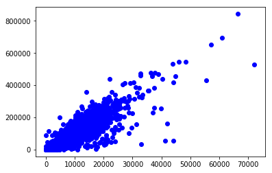

```python
## first we will desctbe the relationship between number of patients and total cost

x = pats_cost_prac_claean['NUMBER_OF_PATIENTS']
y = pats_cost_prac_claean['total_cost']

plt.plot(x, y, 'o', color='blue');
```

## Analysis

As can be expected there is a linear relationship between the number of patients  
registerd at a practice and the total prescribing cost for each practice.

# Assignment B

GITHUB:https://github.com/imidean1/DMHR-Coursework

first we load all our datasets

```python
import pandasql as psql
import numpy as np
import pandas as pd
import matplotlib as mp
import os as os
os.chdir("/Users/dingo/desktop")
print("Current Working Directory " , os.getcwd())
```

```
Current Working Directory  /Users/dingo/Desktop
```

```python
#Importing Datasets

country_codes= pd.read_csv("country_codes.csv",skipinitialspace=True)

display(country_codes.head(5))
```

|  | country | name |
| --- | --- | --- |
| 0 | 1010 | Algeria |
| 1 | 1020 | Angola |
| 2 | 1025 | Benin |
| 3 | 1030 | Botswana |
| 4 | 1035 | Burkina Faso |

```python
population= pd.read_csv("pop.csv",skipinitialspace=True)

display(population.head(5))
```

|  | Country | Admin1 | SubDiv | Year | Sex | Frmat | Pop1 | Pop2 | Pop3 | Pop4 | ... | Pop18 | Pop19 | Pop20 | Pop21 | Pop22 | Pop23 | Pop24 | Pop25 | Pop26 | Lb |
| --- | --- | --- | --- | --- | --- | --- | --- | --- | --- | --- | --- | --- | --- | --- | --- | --- | --- | --- | --- | --- | --- |
| 0 | 1060 | NaN | NaN | 1980 | 1 | 7 | 137100.0 | 3400.0 | 15800.0 | NaN | ... | NaN | 5300.0 | NaN | 2900.0 | NaN | NaN | NaN | NaN | 6500.0 | 5000.0 |
| 1 | 1060 | NaN | NaN | 1980 | 2 | 7 | 159000.0 | 4000.0 | 18400.0 | NaN | ... | NaN | 6200.0 | NaN | 3400.0 | NaN | NaN | NaN | NaN | 7500.0 | 6000.0 |
| 2 | 1125 | NaN | NaN | 1955 | 1 | 2 | 5051500.0 | 150300.0 | 543400.0 | NaN | ... | 110200.0 | 51100.0 | 41600.0 | 14300.0 | 11800.0 | 25300.0 | NaN | NaN | 0.0 | 253329.0 |
| 3 | 1125 | NaN | NaN | 1955 | 2 | 2 | 5049400.0 | 145200.0 | 551000.0 | NaN | ... | 122100.0 | 51100.0 | 50700.0 | 15800.0 | 18000.0 | 28500.0 | NaN | NaN | 0.0 | 237901.0 |
| 4 | 1125 | NaN | NaN | 1956 | 1 | 2 | 5353700.0 | 158700.0 | 576600.0 | NaN | ... | 116900.0 | 54100.0 | 44000.0 | 14900.0 | 12400.0 | 26600.0 | NaN | NaN | 0.0 | 250022.0 |

5 rows × 33 columns

```python
death1= pd.read_csv("Morticd10_part1.csv",skipinitialspace=True)

display(death1.head(5))
```

|  | Country | Admin1 | SubDiv | Year | List | Cause | Sex | Frmat | IM_Frmat | Deaths1 | ... | Deaths21 | Deaths22 | Deaths23 | Deaths24 | Deaths25 | Deaths26 | IM_Deaths1 | IM_Deaths2 | IM_Deaths3 | IM_Deaths4 |
| --- | --- | --- | --- | --- | --- | --- | --- | --- | --- | --- | --- | --- | --- | --- | --- | --- | --- | --- | --- | --- | --- |
| 0 | 1400 | NaN | NaN | 2001 | 101 | 1000 | 1 | 7 | 8 | 332 | ... | 95.0 | NaN | NaN | NaN | NaN | 0.0 | 8.0 | NaN | NaN | NaN |
| 1 | 1400 | NaN | NaN | 2001 | 101 | 1000 | 2 | 7 | 8 | 222 | ... | 112.0 | NaN | NaN | NaN | NaN | 0.0 | 11.0 | NaN | NaN | NaN |
| 2 | 1400 | NaN | NaN | 2001 | 101 | 1001 | 1 | 7 | 8 | 24 | ... | 5.0 | NaN | NaN | NaN | NaN | 0.0 | 0.0 | NaN | NaN | NaN |
| 3 | 1400 | NaN | NaN | 2001 | 101 | 1001 | 2 | 7 | 8 | 14 | ... | 6.0 | NaN | NaN | NaN | NaN | 0.0 | 0.0 | NaN | NaN | NaN |
| 4 | 1400 | NaN | NaN | 2001 | 101 | 1002 | 1 | 7 | 8 | 0 | ... | 0.0 | NaN | NaN | NaN | NaN | 0.0 | 0.0 | NaN | NaN | NaN |

5 rows × 39 columns

```python
death2= pd.read_csv("Morticd10_part2.csv",skipinitialspace=True)

display(death2.head(5))
```

|  | Country | Admin1 | SubDiv | Year | List | Cause | Sex | Frmat | IM_Frmat | Deaths1 | ... | Deaths21 | Deaths22 | Deaths23 | Deaths24 | Deaths25 | Deaths26 | IM_Deaths1 | IM_Deaths2 | IM_Deaths3 | IM_Deaths4 |
| --- | --- | --- | --- | --- | --- | --- | --- | --- | --- | --- | --- | --- | --- | --- | --- | --- | --- | --- | --- | --- | --- |
| 0 | 1400 | NaN | NaN | 2005 | 101 | 1000 | 1 | 7 | 8 | 386 | ... | 136.0 | NaN | NaN | NaN | NaN | 0.0 | 10.0 | NaN | NaN | NaN |
| 1 | 1400 | NaN | NaN | 2005 | 101 | 1000 | 2 | 7 | 8 | 287 | ... | 163.0 | NaN | NaN | NaN | NaN | 0.0 | 6.0 | NaN | NaN | NaN |
| 2 | 1400 | NaN | NaN | 2005 | 101 | 1001 | 1 | 7 | 8 | 29 | ... | 13.0 | NaN | NaN | NaN | NaN | 0.0 | 0.0 | NaN | NaN | NaN |
| 3 | 1400 | NaN | NaN | 2005 | 101 | 1001 | 2 | 7 | 8 | 21 | ... | 16.0 | NaN | NaN | NaN | NaN | 0.0 | 0.0 | NaN | NaN | NaN |
| 4 | 1400 | NaN | NaN | 2005 | 101 | 1002 | 1 | 7 | 8 | 0 | ... | 0.0 | NaN | NaN | NaN | NaN | 0.0 | 0.0 | NaN | NaN | NaN |

5 rows × 39 columns

## question 1:

Total number of population for each country for 2010 is shown below

```python
# First we calculate total population of each country
from pandasql import PandaSQL
pdsql = PandaSQL()
temp = pdsql('select Country, sum(Pop1) as total_population from population where Country in ("4290","4180","5150","5020") and Year="2010" group by 1 ;')
total_populations=pdsql('select b.name, a.* from temp a left outer join country_codes b on a.Country = b.country;')
display(total_populations)
```

|  | name | Country | total_population |
| --- | --- | --- | --- |
| 0 | Italy | 4180 | 60483386.0 |
| 1 | Sweden | 4290 | 9378126.0 |
| 2 | Australia | 5020 | 22297515.0 |
| 3 | New Zealand | 5150 | 4367360.0 |

total number of deaths forr all causes and all ages during 2010 for each country is

```python
# getting total deaths for each country

total_death=pdsql("select Country, sum(Deaths1) as total_deaths from death2 where country in('4180','4290','5150') and Year ='2010' group by 1;")
total_population_death = pdsql("select a.*, b.total_deaths from total_populations a left outer join total_death b on a.Country = b.Country;")
display(total_population_death)
```

|  | name | Country | total_population | total_deaths |
| --- | --- | --- | --- | --- |
| 0 | Italy | 4180 | 60483386.0 | 1169230.0 |
| 1 | Sweden | 4290 | 9378126.0 | 181038.0 |
| 2 | Australia | 5020 | 22297515.0 | NaN |
| 3 | New Zealand | 5150 | 4367360.0 | 57298.0 |

## Question 2. What was the distribution of deaths (all causes, all years) by age group in Italy?

o Visualise the results using a histogram.

```python
# We will take the Year and Death 1 columns for both datasets, union all then histogram

italy1 = pdsql('select Year, Deaths1 ,Cause from death1 where country= "4180";')
italy2 = pdsql('select Year, Deaths1, Cause from death2 where country= "4180";')
```

```python
italy_dath = pdsql('select * from italy1 UNION ALL select * from italy2 order by Year desc;')
```

```python
italy_death = pdsql('select sum(Deaths1) as total_death,  Year from italy_dath group by 2;')
display(italy_death)
```

|  | total_death | Year |
| --- | --- | --- |
| 0 | 1177794 | 2003 |
| 1 | 1090102 | 2004 |
| 2 | 1136656 | 2005 |
| 3 | 1117228 | 2006 |
| 4 | 1145762 | 2007 |
| 5 | 1162940 | 2008 |
| 6 | 1176876 | 2009 |
| 7 | 1169230 | 2010 |
| 8 | 1188306 | 2011 |
| 9 | 1227040 | 2012 |
| 10 | 1199396 | 2013 |
| 11 | 1197340 | 2014 |
| 12 | 1292096 | 2015 |

```python
from matplotlib import pyplot
mp.pyplot.bar( italy_death['Year'], height=italy_death['total_death'])
```

[output not shown]

```
<BarContainer object of 13 artists>
```

## Question 3: What were the top five causes of death (top five ICD-10 terms) in Italy across all years for the Neoplasm ICD10-category (C00-D48)?

a Generate a table with the cause of death, the number of deaths, and the proportion of overall deaths.

```python
italy_death2 = pdsql('select Cause, sum(Deaths1) as total_death, Year from italy_dath group by 1,3;')
```

```python
neoplasem_deaths_italy = pdsql('select Year, Cause, total_death as Neoplasem_death from italy_death2 where Cause like "C%" or Cause like "DO%" or Cause like "D1%" or Cause like "D2%" or Cause like "D3%" or Cause like "D4%" or Cause like "D41%" or Cause like "D42%" or Cause like "D43%" or Cause like "D44%" or Cause like "D45%" or Cause like "D46%" or Cause like "D47%" or Cause like "D48%" group by 1, 2  order by 3 desc;')
```

```python
# generate a table showing the proportion of deaths due to neoplasem by year

deahts_proportion_neoplasem = pdsql('select a.*, b.total_death from neoplasem_deaths_italy a left outer join italy_death b on a.year = b.year order by Year ; ')
```

```python
deahts_proportion_neoplasem['proportion_neoplasem_death']= deahts_proportion_neoplasem['Neoplasem_death']/deahts_proportion_neoplasem['total_death']
deahts_proportion_neoplasem['percentage_deaths_due_to_cancer'] = deahts_proportion_neoplasem['proportion_neoplasem_death'] * 100

display(deahts_proportion_neoplasem.head(5))
```

|  | Year | Cause | Neoplasem_death | total_death | proportion_neoplasem_death | percentage_deaths_due_to_cancer |
| --- | --- | --- | --- | --- | --- | --- |
| 0 | 2003 | C349 | 31925 | 1177794 | 0.027106 | 2.710576 |
| 1 | 2003 | C509 | 11566 | 1177794 | 0.009820 | 0.982005 |
| 2 | 2003 | C169 | 10555 | 1177794 | 0.008962 | 0.896167 |
| 3 | 2003 | C189 | 9706 | 1177794 | 0.008241 | 0.824083 |
| 4 | 2003 | C259 | 7832 | 1177794 | 0.006650 | 0.664972 |

The top 5 neoplasems that casuded death in italy over all years were

```python
top_5_neoplasems =pdsql('select distinct (Cause) as Cause, sum(Neoplasem_death) as death from deahts_proportion_neoplasem group by 1 order by 2 desc;')
display(top_5_neoplasems.head(5))

# C349 = Malignant neoplasm of unspecified part of bronchus or lung
# C509 = Malignant neoplasm of breast of unspecified site.
# C189 = Malignant neoplasm of colon
# C169 = Malignant neoplasm of stomach
# C259 = Malignant neoplasm of pancreas
```

|  | Cause | death |
| --- | --- | --- |
| 0 | C349 | 426451 |
| 1 | C509 | 155895 |
| 2 | C189 | 143188 |
| 3 | C169 | 125679 |
| 4 | C259 | 120070 |

3b Generate a pie chart to visualize the proportion of deaths.

```python
#Lets sum total cancer deaths by year
cancer_prop_all = pdsql('select distinct(Year) as Year, sum(Neoplasem_death) as cancer_death, total_death from deahts_proportion_neoplasem group by 1 order by 1 ;' )
```

```python
#now we caclualte proportion and percentage

cancer_prop_all['proportion_cancer_death']= cancer_prop_all['cancer_death']/cancer_prop_all['total_death']
cancer_prop_all['percentage_cancer_death'] = cancer_prop_all['proportion_cancer_death'] * 100

display(cancer_prop_all)
```

|  | Year | cancer_death | total_death | proportion_cancer_death | percentage_cancer_death |
| --- | --- | --- | --- | --- | --- |
| 0 | 2003 | 167140 | 1177794 | 0.141909 | 14.190937 |
| 1 | 2004 | 166439 | 1090102 | 0.152682 | 15.268204 |
| 2 | 2005 | 166542 | 1136656 | 0.146519 | 14.651926 |
| 3 | 2006 | 168662 | 1117228 | 0.150965 | 15.096471 |
| 4 | 2007 | 171623 | 1145762 | 0.149789 | 14.978940 |
| 5 | 2008 | 172781 | 1162940 | 0.148573 | 14.857258 |
| 6 | 2009 | 174677 | 1176876 | 0.148424 | 14.842430 |
| 7 | 2010 | 175044 | 1169230 | 0.149709 | 14.970878 |
| 8 | 2011 | 175972 | 1188306 | 0.148086 | 14.808644 |
| 9 | 2012 | 177348 | 1227040 | 0.144533 | 14.453319 |
| 10 | 2013 | 176219 | 1199396 | 0.146923 | 14.692312 |
| 11 | 2014 | 177302 | 1197340 | 0.148080 | 14.807991 |
| 12 | 2015 | 178879 | 1292096 | 0.138441 | 13.844095 |

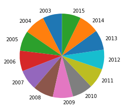

```python
#Now we create pie charts
import matplotlib.pyplot as plt

# Plot
plt.pie(cancer_prop_all['percentage_cancer_death'], labels=cancer_prop_all['Year'],startangle=90)
plt.show()
```

## Question 4. Are there differences by age group for deaths from Neoplasms (C00-D48) in Australia for 2010? Identify the top five age groups in Australia dying with a Neoplasms cause of death.

```python
##Create a dataset of all deaths due to cancer
aust = pdsql('select Cause, Frmat as age_grp, sum(Deaths1) as deaths from death2 where Country = "5020" and Year= "2010" and  Cause like "C%" or Cause like "DO%" or Cause like "D1%" or Cause like "D2%" or Cause like "D3%" or Cause like "D4%" or Cause like "D41%" or Cause like "D42%" or Cause like "D43%" or Cause like "D44%" or Cause like "D45%" or Cause like "D46%" or Cause like "D47%" or Cause like "D48%" group by 1, 2 order by 3 desc;')
```

```python
## age_grp 0 is death for all ages so we will not select it
aust_drop_0 = pdsql('select * from aust where age_grp in("1","2","3","4","5","6","7","8","9");')
```

```python
## findng which age group suffered the most death from cancer in 2010
aust_age_death =pdsql('select age_grp as age_group, sum(deaths) as deaths from aust_drop_0 group by 1 order by 2 desc')
```

```python
display(aust_age_death.head(5))
```

|  | age_group | deaths |
| --- | --- | --- |
| 0 | 1 | 26496 |
| 1 | 2 | 24364 |
| 2 | 4 | 896 |
| 3 | 3 | 37 |
| 4 | 6 | 2 |

### Q5 Compare and contrast the frequency of deaths by Neoplasms in Italy and Australia in 2010.

```python
## Lets calculate number of deaths in Aus 2010
```

```python
temp_2 = pdsql('select Country, sum(Pop1) as total_population from population where Country = "5020" and Year="2010" group by 1 ;')
total_populations_aus=pdsql('select b.name, a.* from temp a left outer join country_codes b on a.Country = b.country;')
display(total_populations_aus)
```

|  | name | Country | total_population |
| --- | --- | --- | --- |
| 0 | Italy | 4180 | 60483386.0 |
| 1 | Sweden | 4290 | 9378126.0 |
| 2 | Australia | 5020 | 22297515.0 |
| 3 | New Zealand | 5150 | 4367360.0 |

```python
aus_1 = pdsql('select Year, Deaths1 ,Cause from death1 where country= "5020" ;')
aus_2 = pdsql('select Year, Deaths1, Cause from death2 where country= "5020" ')
aus_dath = pdsql('select * from aus_1 UNION ALL select * from aus_2 order by Year desc;')
aus_death = pdsql('select sum(Deaths1) as total_death,  Year from aus_dath group by 2;')
```

```python
aus_death2 = pdsql('select Cause, sum(Deaths1) as total_death, Year from aus_dath group by 1,3;')
```

```python
neoplasem_deaths_aus = pdsql('select Year, Cause, total_death as Neoplasem_death from aus_death2 where Cause like "C%" or Cause like "DO%" or Cause like "D1%" or Cause like "D2%" or Cause like "D3%" or Cause like "D4%" or Cause like "D41%" or Cause like "D42%" or Cause like "D43%" or Cause like "D44%" or Cause like "D45%" or Cause like "D46%" or Cause like "D47%" or Cause like "D48%" group by 1, 2  order by 3 desc;')
```

```python
# generate a table showing the proportion of deaths due to neoplasem by year

deahts_proportion_neoplasem_aus = pdsql('select a.*, b.total_death from neoplasem_deaths_aus a left outer join aus_death b on a.year = b.year order by Year ; ')

display(deahts_proportion_neoplasem_aus)
```

|  | Year | Cause | Neoplasem_death | total_death |
| --- | --- | --- | --- | --- |
| 0 | 1998 | C349 | 6386 | 254716 |
| 1 | 1998 | C61 | 2570 | 254716 |
| 2 | 1998 | C509 | 2524 | 254716 |
| 3 | 1998 | C189 | 2418 | 254716 |
| 4 | 1998 | C80 | 2123 | 254716 |
| 5 | 1998 | C259 | 1393 | 254716 |
| 6 | 1998 | C859 | 1190 | 254716 |
| 7 | 1998 | C169 | 1086 | 254716 |
| 8 | 1998 | C20 | 975 | 254716 |
| 9 | 1998 | C159 | 949 | 254716 |
| 10 | 1998 | C439 | 823 | 254716 |
| 11 | 1998 | C679 | 793 | 254716 |
| 12 | 1998 | C64 | 771 | 254716 |
| 13 | 1998 | C56 | 749 | 254716 |
| 14 | 1998 | C900 | 605 | 254716 |
| 15 | 1998 | C719 | 582 | 254716 |
| 16 | 1998 | C920 | 569 | 254716 |
| 17 | 1998 | C187 | 370 | 254716 |
| 18 | 1998 | C97 | 361 | 254716 |
| 19 | 1998 | C220 | 308 | 254716 |
| 20 | 1998 | C180 | 263 | 254716 |
| 21 | 1998 | C539 | 258 | 254716 |
| 22 | 1998 | D469 | 253 | 254716 |
| 23 | 1998 | C911 | 245 | 254716 |
| 24 | 1998 | C19 | 230 | 254716 |
| 25 | 1998 | C341 | 220 | 254716 |
| 26 | 1998 | C450 | 213 | 254716 |
| 27 | 1998 | C250 | 210 | 254716 |
| 28 | 1998 | C260 | 208 | 254716 |
| 29 | 1998 | C221 | 204 | 254716 |
| ... | ... | ... | ... | ... |
| 6266 | 2016 | C942 | 1 | 317008 |
| 6267 | 2016 | C944 | 1 | 317008 |
| 6268 | 2016 | C946 | 1 | 317008 |
| 6269 | 2016 | C947 | 1 | 317008 |
| 6270 | 2016 | C957 | 1 | 317008 |
| 6271 | 2016 | C962 | 1 | 317008 |
| 6272 | 2016 | C966 | 1 | 317008 |
| 6273 | 2016 | C968 | 1 | 317008 |
| 6274 | 2016 | D110 | 1 | 317008 |
| 6275 | 2016 | D126 | 1 | 317008 |
| 6276 | 2016 | D130 | 1 | 317008 |
| 6277 | 2016 | D134 | 1 | 317008 |
| 6278 | 2016 | D137 | 1 | 317008 |
| 6279 | 2016 | D164 | 1 | 317008 |
| 6280 | 2016 | D179 | 1 | 317008 |
| 6281 | 2016 | D219 | 1 | 317008 |
| 6282 | 2016 | D239 | 1 | 317008 |
| 6283 | 2016 | D321 | 1 | 317008 |
| 6284 | 2016 | D330 | 1 | 317008 |
| 6285 | 2016 | D331 | 1 | 317008 |
| 6286 | 2016 | D34 | 1 | 317008 |
| 6287 | 2016 | D382 | 1 | 317008 |
| 6288 | 2016 | D412 | 1 | 317008 |
| 6289 | 2016 | D441 | 1 | 317008 |
| 6290 | 2016 | D445 | 1 | 317008 |
| 6291 | 2016 | D467 | 1 | 317008 |
| 6292 | 2016 | D470 | 1 | 317008 |
| 6293 | 2016 | D477 | 1 | 317008 |
| 6294 | 2016 | D484 | 1 | 317008 |
| 6295 | 2016 | D486 | 1 | 317008 |

6296 rows × 4 columns

```python
cancer_prop_aus = pdsql('select distinct(Year) as Year, sum(Neoplasem_death) as cancer_death, total_death from deahts_proportion_neoplasem_aus group by 1 order by 1 ;' )
```

```python
cancer_prop_aus['proportion_cancer_death']= cancer_prop_aus['cancer_death']/cancer_prop_aus['total_death']
cancer_prop_aus['percentage_cancer_death'] = cancer_prop_aus['proportion_cancer_death'] * 100

display(cancer_prop_aus)
```

|  | Year | cancer_death | total_death | proportion_cancer_death | percentage_cancer_death |
| --- | --- | --- | --- | --- | --- |
| 0 | 1998 | 35673 | 254716 | 0.140050 | 14.005010 |
| 1 | 1999 | 35879 | 256158 | 0.140066 | 14.006590 |
| 2 | 2000 | 36564 | 257568 | 0.141959 | 14.195863 |
| 3 | 2001 | 37459 | 257314 | 0.145577 | 14.557700 |
| 4 | 2002 | 38268 | 266094 | 0.143814 | 14.381384 |
| 5 | 2003 | 38266 | 263568 | 0.145185 | 14.518454 |
| 6 | 2004 | 38883 | 264628 | 0.146935 | 14.693456 |
| 7 | 2006 | 39763 | 267478 | 0.148659 | 14.865896 |
| 8 | 2007 | 40330 | 275708 | 0.146278 | 14.627795 |
| 9 | 2008 | 42422 | 287892 | 0.147354 | 14.735387 |
| 10 | 2009 | 41962 | 281520 | 0.149055 | 14.905513 |
| 11 | 2010 | 43316 | 286946 | 0.150955 | 15.095523 |
| 12 | 2011 | 43737 | 293864 | 0.148834 | 14.883415 |
| 13 | 2012 | 43509 | 294196 | 0.147891 | 14.789120 |
| 14 | 2013 | 44676 | 295356 | 0.151262 | 15.126153 |
| 15 | 2014 | 44740 | 307160 | 0.145657 | 14.565699 |
| 16 | 2015 | 46573 | 318104 | 0.146408 | 14.640809 |
| 17 | 2016 | 46307 | 317008 | 0.146075 | 14.607518 |

```python
cancer_aus_2010 = pdsql('select * from cancer_prop_aus where Year = "2010"  ;' )
```

```python
## The proportion of deaths attributed to cancer in australia during 2010 is:
```

```python
display(cancer_aus_2010)
```

|  | Year | cancer_death | total_death | proportion_cancer_death | percentage_cancer_death |
| --- | --- | --- | --- | --- | --- |
| 0 | 2010 | 43316 | 286946 | 0.150955 | 15.095523 |

```python
# The proportion of deaths attributed to cancer during 2010 in italy is:
```

```python
cancer_italy_2010 = pdsql('select * from cancer_prop_all where Year = "2010"  ;' )
```

```python
display(cancer_italy_2010)
```

|  | Year | cancer_death | total_death | proportion_cancer_death | percentage_cancer_death |
| --- | --- | --- | --- | --- | --- |
| 0 | 2010 | 175044 | 1169230 | 0.149709 | 14.970878 |

# Analysis

#### These same results and trends are validated when checking the projections from the global burden of disease study.